# Hosted Copies, Targeted Updates

## An Alternative, Efficient ETL Strategy with Python

[figure not shown]

# https://github.com/jdcarls2/ilgisa-2022

# Outline

1. What's a "hosted copy"?
2. Common Approaches
3. The Process
4. Discussion
5. Questions?

# What is a "hosted copy", anyway?

## A Common Problem

An organization (say, a county) has datasets that they wish to make available to the public.

*However!*

The authoritative source(s) is/are:

- Not available to register with ArcGIS Server
- Too sensitive to expose outside your organization's network
- Not in the same place (i.e., a SQL view layer is not possible)

## A Common Solution

The organization publishes a "hosted copy" of the data to ArcGIS Online / Portal. The data is loaded into ArcGIS Datastore and served from there.

Now the public can see and interact with the dataset, but the authoritative source remains inaccessible to the rest of the internet. All is well!

## A New Problem!

Suppose the organization's authoritative source is *dynamic*.

How can updates be passed to the hosted layer to ensure that the public sees the most current information?

# Common Approaches

## Overwriting Your Service

**Don't do this!**

When you overwrite a service (*usually done from your desktop software or via `arcpy`*), literally **everything** about the service is wiped out and re-created except for the portal ItemID and the service URL.

**It's like bulldozing your house so you can re-paint the kitchen.**

### When does it make sense?

With hosted layers, this process is necessary if your service:

- Has changed the order / number of its layers
- Has changes to relationship classes

Still, you may be better off making a brand new layer.

### When does it *not* make sense?

- Schema alterations
- Upated features or attributes
- Default symbology / label / popup changes

Portal & AGOL have built-in ways to manage *all* of these. You're much better off making parallel changes to your hosted layer than burning it down.

## Truncate / Append

This method leaves the layer and its schema intact and simply *empties* the layer of all its data, then loads in a fresh set.

In keeping with the house analogy, this is less drastic than bulldozing. It's more like moving all your furniture out of the house, replacing a chair, then putting it all back.

It's a *much* safer approach.

# Targeted Updates

## What's different about this method?

- Compares source / destination data and specifically identifies "stale" rows
- Identifies adds / deletes
- Passes data directly into the destination layer without a separate upload / layer needing to be created
- Can run *per source* on a subset of fields

[figure not shown]

## Key Benefits

Even very large datasets can be refreshed in only a few minutes.

There is *never* a moment when the layer is unresponsive or emptied of its data.

Total server traffic and server-side processing is dramatically diminished.

## Requirements

- Environment
  - ArcGIS Python API
  - Access to source data
  - Portal / AGOL authentication
- Non-Spatial Data Layers
  - Shared primary key between source(s) and destination
- Spatial Data Layers
  - Editor Tracking Timestamps
  - GloablID and GUID field on source and destination, respectively

# Prep Work

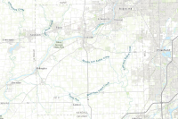

[**Parcels_ILGISA_Demo**](https://kendall.maps.arcgis.com/home/item.html?id=5ab5004c86f341278c6b1d996e551cb4)  
DEMO LAYER. This is not a real layer of parcels. It was created for demonstration purposes only.

[figure not shown]

Feature Layer Collection by carlsonj9  
Last Modified: October 13, 2022  
0 comments, 51 views

```python
# Required Modules
from arcgis.gis import GIS
from arcgis.features import GeoAccessor
import pandas as pd
from datetime import datetime

# Connect to AGOL
gis = GIS(profile='AGOL')

# Get Destination Layer
dest = gis.content.get('5ab5004c86f341278c6b1d996e551cb4')
dlayer = dest.layers[0]

dest
```

## Web Map with Destination Layer

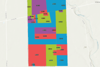

[**Hosted Copy Demo Map**](https://kendall.maps.arcgis.com/home/item.html?id=7a4af15daced43cbb819985dd79aa2c3)

[figure not shown]

Web Map by carlsonj9  
Last Modified: October 13, 2022  
0 comments, 6 views

```python
wm = gis.content.get('7a4af15daced43cbb819985dd79aa2c3')
wm
```

[Link to Map Viewer](https://arcg.is/0u1188)

## Pulling Source Data

### From Spatial File

```python
p_df = GeoAccessor.from_featureclass('../data-files/ilgisa.gdb/parcels')

p_df.head()
```

|  | Shape_Length | Shape_Area | GlobalID | pin | created_user | created_date | last_edited_user | last_edited_date | SHAPE |
| --- | --- | --- | --- | --- | --- | --- | --- | --- | --- |
| 0 | 5276.864891 | 1.100042e+06 | {31FD8039-5E6A-4668-B4A0-037CF22F4451} | 01-06-100-001 | JCARLSON | 2022-10-12T03:03:49+00:00 | JCARLSON | 2022-10-12T03:03:49+00:00 | {"rings": [[[910927.6100513302, 1838427.720154... |
| 1 | 1933.037037 | 2.192212e+05 | {064B7505-4399-4DA3-91AA-1048943A82DB} | 01-06-100-014 | JCARLSON | 2022-10-12T03:03:49+00:00 | JCARLSON | 2022-10-12T03:03:49+00:00 | {"rings": [[[913069.6894285791, 1838405.293033... |
| 2 | 2958.945676 | 4.981201e+05 | {9E897663-5DC9-4F8B-ACB1-DB29CFBA0A26} | 01-06-200-002 | JCARLSON | 2022-10-12T03:03:49+00:00 | JCARLSON | 2022-10-12T03:03:49+00:00 | {"rings": [[[914855.5198464133, 1839151.150137... |
| 3 | 7990.099714 | 3.220557e+06 | {0D0B143F-C3ED-4AFD-B5E1-968977CFB693} | 01-06-200-012 | JCARLSON | 2022-10-12T03:03:49+00:00 | JCARLSON | 2022-10-12T03:03:49+00:00 | {"rings": [[[915239.6099574938, 1840128.820098... |
| 4 | 1308.180869 | 1.064012e+05 | {7E0DBA9F-5804-4DBD-A808-17DADD359C3C} | 01-06-300-004 | JCARLSON | 2022-10-12T03:03:49+00:00 | JCARLSON | 2022-10-12T03:03:49+00:00 | {"rings": [[[914016.6399624944, 1836439.480036... |

### From Non-Spatial Files

```python
a_df = pd.read_excel('../data-files/assessments.xlsx')

a_df = a_df.rename(columns={'parcel_number':'pin'}).set_index('pin', drop=False).fillna('').astype({'property_class':'str'})

a_df.head()
```

| pin | pin | property_class | assessed_value | owner_name | tax_code |
| --- | --- | --- | --- | --- | --- |
| 01-06-100-001 | 01-06-100-001 | 40 | 39603 | Tylor Y Mercado | LR001 |
| 01-06-100-014 | 01-06-100-014 | 11 | 47075 | Johnathon R Corbett | LR001 |
| 01-06-200-002 | 01-06-200-002 | 21 | 14216 | Odalys Hope | LR022 |
| 01-06-200-012 | 01-06-200-012 | 21 | 2660 | Giavanna J Richmond | LR022 |
| 01-06-300-004 | 01-06-300-004 | 11 | 86255 | Matthias Gallant | LR001 |

```python
s_df = pd.read_csv('../data-files/structures.csv').set_index('pin', drop=False)

s_df.head()
```

| pin | pin | structure_type | description | sq_ft | beds | baths | h_baths | primary_yn |
| --- | --- | --- | --- | --- | --- | --- | --- | --- |
| 01-06-100-001 | 01-06-100-001 | 1 story | NaN | 1250 | 2.0 | 1.0 | 1.0 | y |
| 01-06-100-014 | 01-06-100-014 | 2 story | NaN | 2200 | 4.0 | 2.0 | 1.0 | y |
| 01-06-300-004 | 01-06-300-004 | 2 story | NaN | 2100 | 5.0 | 3.0 | 0.0 | y |
| 01-06-300-004 | 01-06-300-004 | other | pole barn | 3000 | NaN | NaN | NaN | n |
| 01-06-300-004 | 01-06-300-004 | other | shed | 350 | NaN | NaN | NaN | n |

# Updating Feature Attributes from Separate Sources

## Assessment Data

### Reshape Data

For an accurate comparison, we need our frames to be the same *shape*. We will do this by:

1. Only looking at destination columns in common with the source
2. Only including rows common to both

```python
a_cols = [
    'pin',
    'property_class',
    'assessed_value',
    'owner_name',
    'tax_code'
]
```

```python
# Query destination, no shapes, subset of fields
dest_a = dlayer.query(
    out_fields=a_cols,
    as_df=True,
    return_geometry=False
).set_index('pin', drop=False)

dest_a.head()
```

| pin | OBJECTID | pin | property_class | assessed_value | owner_name | tax_code |
| --- | --- | --- | --- | --- | --- | --- |
| 01-06-100-001 | 1 | 01-06-100-001 | 40 | 39603 | Tylor Y Mercado | LR001 |
| 01-06-100-014 | 2 | 01-06-100-014 | 11 | 47075 | Johnathon R Corbett | LR001 |
| 01-06-200-002 | 3 | 01-06-200-002 | 21 | 14216 | Odalys Hope |  |
| 01-06-200-012 | 4 | 01-06-200-012 | 21 | 2660 | Giavanna J Richmond |  |
| 01-06-300-004 | 5 | 01-06-300-004 | 11 | 86255 | Matthias Gallant | LR001 |

```python
inner_a = a_df.merge(dest_a[['OBJECTID']], how='inner', left_index=True, right_index=True)

inner_a.head()
```

| pin | pin | property_class | assessed_value | owner_name | tax_code | OBJECTID |
| --- | --- | --- | --- | --- | --- | --- |
| 01-06-100-001 | 01-06-100-001 | 40 | 39603 | Tylor Y Mercado | LR001 | 1 |
| 01-06-100-014 | 01-06-100-014 | 11 | 47075 | Johnathon R Corbett | LR001 | 2 |
| 01-06-200-002 | 01-06-200-002 | 21 | 14216 | Odalys Hope | LR022 | 3 |
| 01-06-200-012 | 01-06-200-012 | 21 | 2660 | Giavanna J Richmond | LR022 | 4 |
| 01-06-300-004 | 01-06-300-004 | 11 | 86255 | Matthias Gallant | LR001 | 5 |

```python
# Sort frames the same, just in case
for df in [inner_a, dest_a]:
    df.sort_index(inplace=True)

# Get columns in same order
dest_a = dest_a[inner_a.columns.to_list()]
```

```python
comp_a = inner_a.compare(dest_a.loc[inner_a.index,:])

comp_a
```

| pin | tax_code self | tax_code other |
| --- | --- | --- |
| 01-06-100-003 | LR022 |  |
| 01-06-100-005 | LR022 |  |
| 01-06-100-012 | LR022 |  |
| 01-06-100-015 | LR022 |  |
| 01-06-200-002 | LR022 |  |
| 01-06-200-003 | LR022 |  |
| 01-06-200-004 | LR022 | LR003 |
| 01-06-200-012 | LR022 |  |
| 01-06-300-002 | LR022 |  |
| 01-06-300-005 | LR022 |  |
| 01-06-300-006 | LR022 |  |
| 01-06-400-003 | LR022 |  |
| 01-07-100-002 | LR022 |  |
| 01-07-200-004 | LR022 | LR003 |
| 01-07-200-007 | LR022 |  |

```python
inner_a.loc[comp_a.index,:]
```

| pin | pin | property_class | assessed_value | owner_name | tax_code | OBJECTID |
| --- | --- | --- | --- | --- | --- | --- |
| 01-06-100-003 | 01-06-100-003 | 30 | 33296 | Carolina J Winston | LR022 | 7 |
| 01-06-100-005 | 01-06-100-005 | 30 | 88728 | Wayne V Whitworth | LR022 | 8 |
| 01-06-100-012 | 01-06-100-012 | 21 | 90056 | Morris C Pyle | LR022 | 29 |
| 01-06-100-015 | 01-06-100-015 | 21 | 33494 | Zackary J Diamond | LR022 | 13 |
| 01-06-200-002 | 01-06-200-002 | 21 | 14216 | Odalys Hope | LR022 | 3 |
| 01-06-200-003 | 01-06-200-003 | 30 | 66988 | Taniya G Stearns | LR022 | 21 |
| 01-06-200-004 | 01-06-200-004 | 40 | 74178 | Maegan D Carson | LR022 | 22 |
| 01-06-200-012 | 01-06-200-012 | 21 | 2660 | Giavanna J Richmond | LR022 | 4 |
| 01-06-300-002 | 01-06-300-002 | 21 | 68782 | Kade S Heath | LR022 | 16 |
| 01-06-300-005 | 01-06-300-005 | 21 | 31039 | Zain Lanier | LR022 | 19 |
| 01-06-300-006 | 01-06-300-006 | 30 | 50060 | Leonard Lipscomb | LR022 | 20 |
| 01-06-400-003 | 01-06-400-003 | 21 | 24986 | Aidan G Fitzpatrick | LR022 | 6 |
| 01-07-100-002 | 01-07-100-002 | 21 | 81918 | Dawn K Loomis | LR022 | 17 |
| 01-07-200-004 | 01-07-200-004 | 11 | 22805 | Hollie Meador | LR022 | 18 |
| 01-07-200-007 | 01-07-200-007 | 21 | 14094 | Caitlynn Alley | LR022 | 26 |

```python
changes_a = len(comp_a) > 0
print(f'{len(comp_a)} changes identified.' if changes_a else 'No changes!')

update_a = inner_a.loc[comp_a.index,:]

update_a
```

```
15 changes identified.
```

| pin | pin | property_class | assessed_value | owner_name | tax_code | OBJECTID |
| --- | --- | --- | --- | --- | --- | --- |
| 01-06-100-003 | 01-06-100-003 | 30 | 33296 | Carolina J Winston | LR022 | 7 |
| 01-06-100-005 | 01-06-100-005 | 30 | 88728 | Wayne V Whitworth | LR022 | 8 |
| 01-06-100-012 | 01-06-100-012 | 21 | 90056 | Morris C Pyle | LR022 | 29 |
| 01-06-100-015 | 01-06-100-015 | 21 | 33494 | Zackary J Diamond | LR022 | 13 |
| 01-06-200-002 | 01-06-200-002 | 21 | 14216 | Odalys Hope | LR022 | 3 |
| 01-06-200-003 | 01-06-200-003 | 30 | 66988 | Taniya G Stearns | LR022 | 21 |
| 01-06-200-004 | 01-06-200-004 | 40 | 74178 | Maegan D Carson | LR022 | 22 |
| 01-06-200-012 | 01-06-200-012 | 21 | 2660 | Giavanna J Richmond | LR022 | 4 |
| 01-06-300-002 | 01-06-300-002 | 21 | 68782 | Kade S Heath | LR022 | 16 |
| 01-06-300-005 | 01-06-300-005 | 21 | 31039 | Zain Lanier | LR022 | 19 |
| 01-06-300-006 | 01-06-300-006 | 30 | 50060 | Leonard Lipscomb | LR022 | 20 |
| 01-06-400-003 | 01-06-400-003 | 21 | 24986 | Aidan G Fitzpatrick | LR022 | 6 |
| 01-07-100-002 | 01-07-100-002 | 21 | 81918 | Dawn K Loomis | LR022 | 17 |
| 01-07-200-004 | 01-07-200-004 | 11 | 22805 | Hollie Meador | LR022 | 18 |
| 01-07-200-007 | 01-07-200-007 | 21 | 14094 | Caitlynn Alley | LR022 | 26 |

```python
if changes_a:
    a_adds = dlayer.edit_features(updates=update_a.spatial.to_featureset())
    print(f"Updates: {len(a_adds['updateResults'])}")
else:
    print('Nothing to update, no edits made.')
```

```
Updates: 15
```

## (Mostly) The Same Thing, but Structure Data

```python
s_df.query('primary_yn == "n"')
```

| pin | pin | structure_type | description | sq_ft | beds | baths | h_baths | primary_yn |
| --- | --- | --- | --- | --- | --- | --- | --- | --- |
| 01-06-300-004 | 01-06-300-004 | other | pole barn | 3000 | NaN | NaN | NaN | n |
| 01-06-300-004 | 01-06-300-004 | other | shed | 350 | NaN | NaN | NaN | n |
| 01-06-100-013 | 01-06-100-013 | other | horse barn | 4500 | NaN | NaN | NaN | n |
| 01-06-100-013 | 01-06-100-013 | other | garage | 1000 | NaN | NaN | NaN | n |

```python
s_df.drop(s_df.query('primary_yn == "n"').index, inplace=True)

s_df.query('primary_yn == "n"')
```

|  | pin | structure_type | description | sq_ft | beds | baths | h_baths | primary_yn |
| --- | --- | --- | --- | --- | --- | --- | --- | --- |
| pin |  |  |  |  |  |  |  |  |

```python
s_cols = {
    'pin':'pin',
    'structure_type':'struct_type',
    'sq_ft':'struct_sqft',
    'beds':'struct_beds',
    'baths':'struct_baths',
    'h_baths':'struct_hbaths'
}

s_df.rename(columns=s_cols, inplace=True)

s_df.drop(columns=[c for c in s_df.columns if c not in list(s_cols.values())], inplace=True)

s_df.head()
```

| pin | pin | struct_type | struct_sqft | struct_beds | struct_baths | struct_hbaths |
| --- | --- | --- | --- | --- | --- | --- |
| 01-06-100-001 | 01-06-100-001 | 1 story | 1250 | 2.0 | 1.0 | 1.0 |
| 01-06-100-014 | 01-06-100-014 | 2 story | 2200 | 4.0 | 2.0 | 1.0 |
| 01-06-100-016 | 01-06-100-016 | 1 story | 1420 | 3.0 | 1.0 | 1.0 |
| 01-06-100-006 | 01-06-100-006 | 2 story | 1675 | 3.0 | 2.0 | 0.0 |
| 01-07-200-005 | 01-07-200-005 | 2 story | 1800 | 4.0 | 3.0 | 0.0 |

```python
# Query destination, no shapes, subset of fields
dest_s = dlayer.query(
    out_fields=list(s_cols.values()),
    as_df=True,
    return_geometry=False
).set_index('pin', drop=False).fillna('')

inner_s = s_df.merge(dest_a[['OBJECTID']], how='inner', left_index=True, right_index=True)

for df in [inner_s, dest_s]:
    df.sort_index(inplace=True)

dest_s = dest_s[inner_s.columns.to_list()]

comp_s = inner_s.compare(dest_s.loc[inner_s.index,:])

changes_s = len(comp_s) > 0

print(f'{len(comp_s)} changes identified.' if changes_s else 'No changes!')

update_s = inner_s.loc[comp_s.index,:]

if changes_s:
    s_adds = dlayer.edit_features(updates=update_s.spatial.to_featureset())
    print(f"Updates: {len(s_adds['updateResults'])}")
else:
    print('Nothing to update, no edits made.')
```

```
2 changes identified.
Updates: 2
```

# Spatial Stuff

## Last Update Timstamp

In order to filter our edits, we need some other reference date. You can store this in a config file, use the current date, etc.

```python
parcel_last_update = pd.Timestamp(datetime.now()) - pd.Timedelta(days=2)

parcel_last_update
```

```
Timestamp('2022-10-10 21:24:14.248007')
```

```python
p_df.loc[:,'last_edited_date'] = p_df.loc[:,'last_edited_date'].astype('datetime64[ns]')
```

## GUID Formatting

Here in AGOL, the GUID comes through as an un-bracketed string of numbers and *lower-case* alpha characteres. The corresponding GlobalID in the GeoDatabase comes in bracketed and with capitals.

This may not be the case with all sources / destinations. Since it *is* the case here, we'll do a quick string operation to reformat it.

```python
p_df.loc[:,'GlobalID'] = p_df.loc[:,'GlobalID'].str.lower().replace('{|}', '', regex=True)

p_df.loc[:,'GlobalID'].sample()
```

```
8    1d055211-8888-49ad-86ad-d3e48d991c6e
Name: GlobalID, dtype: object
```

## Getting Recent Records

```python
recents = p_df[p_df['last_edited_date'] > parcel_last_update]
recents.drop(columns=[c for c in recents.columns.to_list() if c not in ['GlobalID', 'SHAPE', 'pin']], inplace=True)
recents.rename(columns={'GlobalID':'origin_guid'}, inplace=True)

recents.head()
```

|  | origin_guid | pin | SHAPE |
| --- | --- | --- | --- |
| 0 | 31fd8039-5e6a-4668-b4a0-037cf22f4451 | 01-06-100-001 | {"rings": [[[910927.6100513302, 1838427.720154... |
| 1 | 064b7505-4399-4da3-91aa-1048943a82db | 01-06-100-014 | {"rings": [[[913069.6894285791, 1838405.293033... |
| 2 | 9e897663-5dc9-4f8b-acb1-db29cfba0a26 | 01-06-200-002 | {"rings": [[[914855.5198464133, 1839151.150137... |
| 3 | 0d0b143f-c3ed-4afd-b5e1-968977cfb693 | 01-06-200-012 | {"rings": [[[915239.6099574938, 1840128.820098... |
| 4 | 7e0dba9f-5804-4dbd-a808-17dadd359c3c | 01-06-300-004 | {"rings": [[[914016.6399624944, 1836439.480036... |

## Query Hosted Features

```python
dest_p = dlayer.query(
    as_df = True,
    out_fields = ['origin_guid'],
    return_geometry = False
)

dest_p.head()
```

|  | OBJECTID | origin_guid |
| --- | --- | --- |
| 0 | 1 | 31fd8039-5e6a-4668-b4a0-037cf22f4451 |
| 1 | 2 | 064b7505-4399-4da3-91aa-1048943a82db |
| 2 | 3 | 9e897663-5dc9-4f8b-acb1-db29cfba0a26 |
| 3 | 4 | 0d0b143f-c3ed-4afd-b5e1-968977cfb693 |
| 4 | 5 | 7e0dba9f-5804-4dbd-a808-17dadd359c3c |

### Use `merge` to Identify Adds, Updates, Deletes

| Type | Identification: `origin_guid`... |
| --- | --- |
| Add | ...only exists in source, not destination |
| Delete | ...only exists in destination, not source |
| Update | ...is in both tables, but last edit timestamp was within selected range |

```python
p_add_df = recents.merge(dest_p, how='outer', on='origin_guid', indicator=True).query('_merge == "left_only"')

if len(p_add_df) > 0:
    p_adds = p_add_df.spatial.to_featureset()
    print(f'{len(p_add_df)} features to add')
else:
    p_adds = None
    print('Nothing to add.')
```

```
Nothing to add.
```

```python
p_del = p_df[['GlobalID']].merge(dest_p, how='outer', left_on='GlobalID', right_on='origin_guid', indicator=True).query('_merge == "right_only"')

p_del.head()
```

|  | GlobalID | OBJECTID | origin_guid | _merge |
| --- | --- | --- | --- | --- |

```python
p_update_df = recents.merge(dest_p, how='inner', on='origin_guid')

if len(p_update_df) > 0:
    p_updates = p_update_df.spatial.to_featureset()
    print(f'{len(p_update_df)} features to update')
else:
    p_updates = None
    print('Nothing to update')
```

```
29 features to update
```

## Submit the Adds / Updates / Deletes to the Destination Layer

```python
p_edits = dlayer.edit_features(
    adds = p_adds,
    updates = p_updates,
    deletes = p_del['OBJECTID'].astype('int').to_list())

print(f"Adds: {len(p_edits['addResults'])}\nUpdates: {len(p_edits['updateResults'])}\nDeletes: {len(p_edits['deleteResults'])}")
```

```
Adds: 0
Updates: 29
Deletes: 0
```

# Further Enhancements

1. Logging script results
2. Storing last update timestamps
3. Select not just updated *rows*, but columns as well
4. Incorporating spatial operations in the script (overlays, spatial joins, etc)